# R Tutorial: Github and Tidyverse

Chris LeBoa

5082019

# Github and Tidyverse

This tutorial was taken from our coding club from Univ of Ettinburough

I lost the notes I was taking on it at first Basically Github is great and allows for version control

With new repo you commit - publish firle to Github for 1st time pull - take file from github push - put changes on file up onto Github

This project is synced with Github

## Once is synced there are changes on the doc

Top left - working directory name Top right - new git tab - allows for version control Bottom Right - all files from github are now on computer too

I am having problems with Git not wanting to see the files I am working on

I moved this file to the git folder on my computer but it is still not working

Ok it seems to be working now - i followed a lot of help prompts and need to make sure to save the git repository as the same as the repository where I am already working on docs When making changes - commit to get local version control but then push for new version control on the web

Use fork to copy a github repository to anotehr github account

# Tidyverse

Supposed to make Data easier to work with Need to load some packages that are within the universe seperately

### Libraries

```r
# Install Packages ----
install.packages("ggExtra")
```

```
Error in install.packages : Updating loaded packages
```

```r
install.packages("maps")
```

```
Error in install.packages : Updating loaded packages
```

```r
installed.packages("gridExtra")
```

[output not shown]

```r
# Load Packages ----
library(tidyverse)  # Hadley Wickham's tidyverse - the theme of this tutorial
library(broom)  # To summarise model outputs
library(ggExtra)  # To make pretty graphs - addon package to ggplot2
library(maps)  # To make pretty maps - warning: maps masks map from purr!
library(RColorBrewer)  # To make pretty colours
library(gridExtra)  # To arrange multi-plot panels
```

# Making graphs in ggplot 2

ggplot seems like the bset way to make graphs in R Instead of using a lot of theme comments can make a function

Benefit of function is that it can then be applied later on without having to be rewritten

### Functions

```r
# Setting a custom ggplot2 function ---
# *** Functional Programming ***
# This function makes a pretty ggplot theme
# This function takes no arguments!
theme_LPD <- function(){
  theme_bw()+
    theme(axis.text.x = element_text(size = 12, vjust = 1, hjust = 1),
          axis.text.y = element_text(size = 12),
          axis.title.x = element_text(size = 14, face = "plain"),
          axis.title.y = element_text(size = 14, face = "plain"),
          panel.grid.major.x = element_blank(),
          panel.grid.minor.x = element_blank(),
          panel.grid.minor.y = element_blank(),
          panel.grid.major.y = element_blank(),
          plot.margin = unit(c(0.5, 0.5, 0.5, 0.5), units = , "cm"),
          plot.title = element_text(size = 20, vjust = 1, hjust = 0.5),
          legend.text = element_text(size = 12, face = "italic"),
          legend.title = element_blank(),
          legend.position = c(0.5, 0.8))
}
```

### Load Data

```r
# Load data ----
load("/Users/ChrisLeBoa/Documents/R_Scripts/Learning R Better/R Tutorials/Github and Tidyverse/CC-Ghent-master/LPDdata_Feb2016.RData")
# Inspect data ----
head(LPDdata_Feb2016)
```

|  | id | Data.source.citation | Class | Order | Family | Genus | Species | Sub.species | Authority | Common.Name | Location.of.population | Country.list | Region | Decimal.Latitude | Decimal.Longitude | Are.coordinates.for.specific.location. | system | biome | realm | Native | Alien | Invasive | Units | Sampling.method | Data.transformed | X1970 | X1971 | X1972 | X1973 | … |
| --- | --- | --- | --- | --- | --- | --- | --- | --- | --- | --- | --- | --- | --- | --- | --- | --- | --- | --- | --- | --- | --- | --- | --- | --- | --- | --- | --- | --- | --- | --- |
| 1 | 7399 | Kayser, Y., C. Girard, et al. (2003). COMPTE-RENDU ORNITHOLOGIQUE CAMARGUAIS POUR LES ANN\xed\x8aES 1995-2000. Rev. \xed\x8acol. (Terre Vie) 58: 5-76.\| Kayser Y. M. Gauthier-Clerc et al. (2008). COMP… | Aves | Charadriiformes | Laridae | Larus | genei |  | Br\xed\xc2me, 1839 | Slender-billed gull | Camargue | France | Europe | 43.56667 | 4.56667 | FALSE | Freshwater | Temperate coastal rivers | Palearctic | Yes | No | No | Nests | nest count | No | 0 | NA | NA | 13.0 | … |
| 2 | 5101 | Karenge, L. and J. Kolding (1995). Inshore fish populations and species change in Lake Kariba, Zimbabwe. The Impact of Species Changes in African Lakes. T. J. Pitcher and P. J. B. Hart. London, Chapma… | Actinopterygii | Cypriniformes | Cyprinidae | Labeo | altivelis |  | Peters, 1852 | Rednose labeo | Lake Kariba, Zimbabwe | Zimbabwe | Africa | -16.99833 | 27.99389 | FALSE | Freshwater | Tropical and subtropical floodplain rivers and wetland complexes | Afrotropical | Yes | No | No | CPUE (kg/set) | Fishing | No | 0 | 0 | 0 | 0.5 | … |
| 3 | 5101 | Karenge, L. and J. Kolding (1995). Inshore fish populations and species change in Lake Kariba, Zimbabwe. The Impact of Species Changes in African Lakes. T. J. Pitcher and P. J. B. Hart. London, Chapma… | Actinopterygii | Cypriniformes | Cyprinidae | Labeo | altivelis |  | Peters, 1852 | Rednose labeo | Lake Kariba, Zimbabwe | Zimbabwe | Africa | -16.99833 | 27.99389 | FALSE | Freshwater | Tropical and subtropical floodplain rivers and wetland complexes | Afrotropical | Yes | No | No | CPUE (kg/set) | Fishing | No | 0 | 0 | 0 | 0.5 | … |
| 4 | 5098 | Karenge, L. and J. Kolding (1995). Inshore fish populations and species change in Lake Kariba, Zimbabwe. The Impact of Species Changes in African Lakes. T. J. Pitcher and P. J. B. Hart. London, Chapma… | Actinopterygii | Siluriformes | Mochokidae | Synodontis | zambezensis |  | Peters, 1852 | Plain squeaker | Lake Kariba, Zimbabwe | Zimbabwe | Africa | -16.99833 | 27.99389 | FALSE | Freshwater | Tropical and subtropical floodplain rivers and wetland complexes | Afrotropical | Yes | No | No | CPUE (kg/set) | Fishing | No | 0 | 0 | 0 | 0.0 | … |
| 5 | 1952 | Duck, C. (2002). Annex II - Pup Production in the British Grey Seal Population. UK Special Committee on Seals, Scientific Advice on Matters Related to the Management of Seal Populations. | Mammalia | Carnivora | Phocidae | Halichoerus | grypus |  | (Fabricius, 1791) | Grey seal | Auskerry, Orkney Islands | United Kingdom | Europe | 59.03333 | -2.56667 | TRUE | Marine | Unknown | Atlantic north temperate | Yes | No | No | Pup production estimates | Counts from aerial survey photographs | No | 0 | 0 | NA | 87.0 | … |
| 6 | 1953 | Duck, C. (2002). Annex II - Pup Production in the British Grey Seal Population. UK Special Committee on Seals, Scientific Advice on Matters Related to the Management of Seal Populations. | Mammalia | Carnivora | Phocidae | Halichoerus | grypus |  | (Fabricius, 1791) | Grey seal | Calf of Eday | United Kingdom | Europe | 59.23389 | -2.73361 | TRUE | Marine | Unknown | Atlantic north temperate | Yes | No | No | Pup production estimates for islands in the Orkney group | Counts from aerial survey photographs | No | 0 | 0 | NA | 0.0 | … |

```r
# Format data for analysis ----
# Transform from wide to long format usign gather (opposite is spread)
# *** gather() function from the dplyr package in the tidyverse ***
LPD_long <- gather(data = LPDdata_Feb2016, key = "year", value = "pop", select = 26:70)
```

In the new long dataset the Year variable was made a character - use parse to make it a number and remove the X’s

Also should rename the data

### Format Data

```r
# Get rid of the X in front of years
# *** parse_number() from the readr package in the tidyverse ***
LPD_long$year <- parse_number(LPD_long$year)
# Rename variable names for consistency
names(LPD_long)
```

```
 [1] "id"                                     "Data.source.citation"                   "Class"
 [4] "Order"                                  "Family"                                 "Genus"
 [7] "Species"                                "Sub.species"                            "Authority"
[10] "Common.Name"                            "Location.of.population"                 "Country.list"
[13] "Region"                                 "Decimal.Latitude"                       "Decimal.Longitude"
[16] "Are.coordinates.for.specific.location." "system"                                 "biome"
[19] "realm"                                  "Native"                                 "Alien"
[22] "Invasive"                               "Units"                                  "Sampling.method"
[25] "Data.transformed"                       "year"                                   "pop"
```

```r
names(LPD_long) <- tolower(names(LPD_long))
names(LPD_long)
```

```
 [1] "id"                                     "data.source.citation"                   "class"
 [4] "order"                                  "family"                                 "genus"
 [7] "species"                                "sub.species"                            "authority"
[10] "common.name"                            "location.of.population"                 "country.list"
[13] "region"                                 "decimal.latitude"                       "decimal.longitude"
[16] "are.coordinates.for.specific.location." "system"                                 "biome"
[19] "realm"                                  "native"                                 "alien"
[22] "invasive"                               "units"                                  "sampling.method"
[25] "data.transformed"                       "year"                                   "pop"
```

```r
# Create new column with genus and species together
LPD_long$species.name <- paste(LPD_long$genus, LPD_long$species, sep = " ")
# Get rid of strange characters like " / "
LPD_long$country.list <- gsub(",", "", LPD_long$country.list, fixed = TRUE)
LPD_long$biome <- gsub("/", "", LPD_long$biome, fixed = TRUE)
# Examine the tidy data frame
head(LPD_long)
```

|  | id | data.source.citation | class | order | family | genus | species | sub.species | authority | common.name | location.of.population | country.list | region | decimal.latitude | decimal.longitude | are.coordinates.for.specific.location. | system | biome | realm | native | alien | invasive | units | sampling.method | data.transformed | year | pop | species.name |
| --- | --- | --- | --- | --- | --- | --- | --- | --- | --- | --- | --- | --- | --- | --- | --- | --- | --- | --- | --- | --- | --- | --- | --- | --- | --- | --- | --- | --- |
| 1 | 7399 | Kayser, Y., C. Girard, et al. (2003). COMPTE-RENDU ORNITHOLOGIQUE CAMARGUAIS POUR LES ANN\xed\x8aES 1995-2000. Rev. \xed\x8acol. (Terre Vie) 58: 5-76.\| Kayser Y. M. Gauthier-Clerc et al. (2008). COMP… | Aves | Charadriiformes | Laridae | Larus | genei |  | Br\xed\xc2me, 1839 | Slender-billed gull | Camargue | France | Europe | 43.56667 | 4.56667 | FALSE | Freshwater | Temperate coastal rivers | Palearctic | Yes | No | No | Nests | nest count | No | 1970 | 0 | Larus genei |
| 2 | 5101 | Karenge, L. and J. Kolding (1995). Inshore fish populations and species change in Lake Kariba, Zimbabwe. The Impact of Species Changes in African Lakes. T. J. Pitcher and P. J. B. Hart. London, Chapma… | Actinopterygii | Cypriniformes | Cyprinidae | Labeo | altivelis |  | Peters, 1852 | Rednose labeo | Lake Kariba, Zimbabwe | Zimbabwe | Africa | -16.99833 | 27.99389 | FALSE | Freshwater | Tropical and subtropical floodplain rivers and wetland complexes | Afrotropical | Yes | No | No | CPUE (kg/set) | Fishing | No | 1970 | 0 | Labeo altivelis |
| 3 | 5101 | Karenge, L. and J. Kolding (1995). Inshore fish populations and species change in Lake Kariba, Zimbabwe. The Impact of Species Changes in African Lakes. T. J. Pitcher and P. J. B. Hart. London, Chapma… | Actinopterygii | Cypriniformes | Cyprinidae | Labeo | altivelis |  | Peters, 1852 | Rednose labeo | Lake Kariba, Zimbabwe | Zimbabwe | Africa | -16.99833 | 27.99389 | FALSE | Freshwater | Tropical and subtropical floodplain rivers and wetland complexes | Afrotropical | Yes | No | No | CPUE (kg/set) | Fishing | No | 1970 | 0 | Labeo altivelis |
| 4 | 5098 | Karenge, L. and J. Kolding (1995). Inshore fish populations and species change in Lake Kariba, Zimbabwe. The Impact of Species Changes in African Lakes. T. J. Pitcher and P. J. B. Hart. London, Chapma… | Actinopterygii | Siluriformes | Mochokidae | Synodontis | zambezensis |  | Peters, 1852 | Plain squeaker | Lake Kariba, Zimbabwe | Zimbabwe | Africa | -16.99833 | 27.99389 | FALSE | Freshwater | Tropical and subtropical floodplain rivers and wetland complexes | Afrotropical | Yes | No | No | CPUE (kg/set) | Fishing | No | 1970 | 0 | Synodontis zambezensis |
| 5 | 1952 | Duck, C. (2002). Annex II - Pup Production in the British Grey Seal Population. UK Special Committee on Seals, Scientific Advice on Matters Related to the Management of Seal Populations. | Mammalia | Carnivora | Phocidae | Halichoerus | grypus |  | (Fabricius, 1791) | Grey seal | Auskerry, Orkney Islands | United Kingdom | Europe | 59.03333 | -2.56667 | TRUE | Marine | Unknown | Atlantic north temperate | Yes | No | No | Pup production estimates | Counts from aerial survey photographs | No | 1970 | 0 | Halichoerus grypus |
| 6 | 1953 | Duck, C. (2002). Annex II - Pup Production in the British Grey Seal Population. UK Special Committee on Seals, Scientific Advice on Matters Related to the Management of Seal Populations. | Mammalia | Carnivora | Phocidae | Halichoerus | grypus |  | (Fabricius, 1791) | Grey seal | Calf of Eday | United Kingdom | Europe | 59.23389 | -2.73361 | TRUE | Marine | Unknown | Atlantic north temperate | Yes | No | No | Pup production estimates for islands in the Orkney group | Counts from aerial survey photographs | No | 1970 | 0 | Halichoerus grypus |

# Data Manipulation

Piping is the easiest way to manipulate data each %>% allows for a manipulation and uses the outcome of the one previously

```r
# Data manipulation ----
# *** piping from from dplyr
LPD_long2 <- LPD_long %>%
  # Remove duplicate rows
  # *** distinct() function from dplyr
  distinct(LPD_long) %>%
  # remove NAs in the population column
  # *** filter() function from dplyr
  filter(is.finite(pop)) %>%
  # Group rows so that each group is one population
  # *** group_by() function from dplyr
  group_by(id) %>%
  # Make some calculations
  # *** mutate() function from dplyr
  mutate(maxyear = max(year), minyear = min(year),
         # Calculate duration
         duration = maxyear - minyear,
         # Scale population trend data
         scalepop = (pop - min(pop))/(max(pop) - min(pop))) %>%
  # Keep populations with >5 years worth of data and calculate length of monitoring
  filter(is.finite(scalepop),
         length(unique(year)) > 5) %>%
  # Remove any groupings you've greated in the pipe
  ungroup()
```

```
Trying to compute distinct() for variables not found in the data:
- `LPD_long`
This is an error, but only a warning is raised for compatibility reasons.
The operation will return the input unchanged.
```

This section stores some summary statistics in a new data frame

```r
# Calculate summary statistics for each biome
LPD_biome_sum <- LPD_long2 %>%
  # Group by biome
  group_by(biome) %>%
  # Create columns, number of populations
  #  *** summarise()/summarize() function from dplyr in the tidyverse ***
  summarise(populations = n(),
            # Calculate the mean study length
            mean_study_length_years = mean(duration),
            # Model sampling method
            dominant_sampling_method = names(which.max(table(sampling.method))),
            # Model unit type
            dominant_units = names(which.max(table(units)))) %>%
  # Remove any groupings you've greated in the pipe
  ungroup()
# Take a look at some of the records
head(LPD_biome_sum)
```

| biome | populations | mean_study_length_years | dominant_sampling_method | dominant_units |
| --- | --- | --- | --- | --- |
| Boreal foreststaiga | 47231 | 38.95183 | Volunteer survey of set routes during peak breeding season | Annual Index |
| Deserts and xeric shrublands | 533 | 17.41276 | capture mark recapture | Number of individuals |
| Flooded grasslands and savannas | 84 | 16.92857 | Expert assessment based on tiger tracks | Number of independent tigers |
| Large lakes | 5917 | 30.55839 | Volunteer survey of set routes during peak breeding season | Annual Index |
| Mangroves | 6 | 11.00000 | Unknown | Breeding pairs |
| Mediterranean forests woodlands and scrub | 3401 | 16.90944 | number of individuals caught in net for bird ringing activities | Individuals |

Want to do further analysis with just 2 groups

Use the filter() function to seperate out the groups

```r
# Subset to just temperate forest species -----
  # Notice the difference between | and & when filtering
  # | is an "or" whereas & is "and", i.e. both conditions have to be met
  # at the same time
LPD_long2$biome <- as.factor(LPD_long2$biome)
LPD.forest <- filter(LPD_long2, biome == "Temperate broadleaf and mixed forests" |
                                      biome == "Temperate coniferous forests")
```

# GGPlot2 Basics —-

Basic syntax for ggplot is ggplot(your_data, aes(x = independent_variable, y = dependent_variable)) then add type of plot want + geom_boxplot(), + geom_histogram()

If want to change color use colour = within aes() with the function made above it is inserted as a theme below the rest of the plotting instructions : look for theme LPD below

put entire thing in () to get it to graph immediately

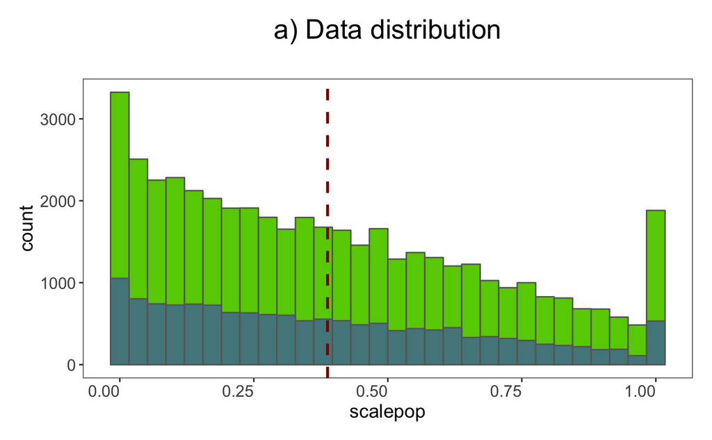

```r
# Data visualisation ----
# Data distribution - a histogram
(forest.hist <- ggplot(LPD.forest, aes(x = scalepop)) +
   geom_histogram(aes(fill = biome),
                  position = "identity", colour = "grey40") +
   geom_vline(aes(xintercept = mean(scalepop)),  # Adding a line for mean abundance
              colour = "darkred", linetype = "dashed", size = 1) +
   scale_fill_manual(values = c("#66CD00", "#53868B")) +
   theme_LPD() +
   labs(title = "a) Data distribution\n") +
   guides(fill = F)) # Hiding the legend - this will be a two plot panel
```

```r
# thus we don't need the same legend twice
```

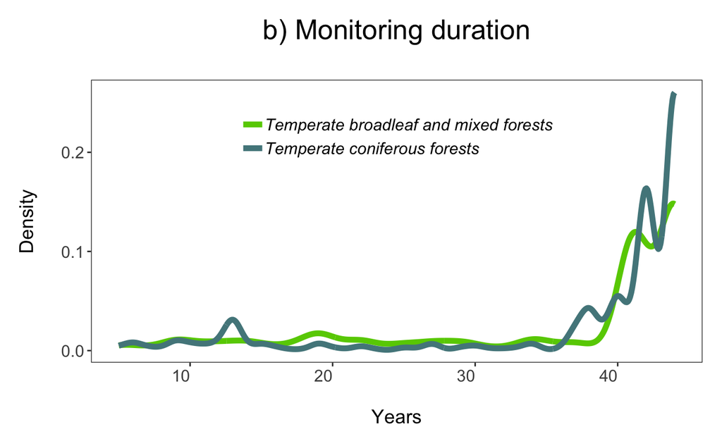

```r
# Density histogram of duration of studies in the two biomes
(duration.forests <- ggplot(LPD.forest, aes(duration, colour = biome)) +
   stat_density(geom = "line", size = 2, position = "identity") +
   theme_LPD() +
   scale_colour_manual(values = c("#66CD00", "#53868B")) +
   labs(x = "\nYears", y = "Density\n", title = "b) Monitoring duration\n"))
```

### Arrangement in GGplot

You can put graphs next to each other in ggplot with grid arrange from the gridExtra package - so can put a bunch of figures in a single file

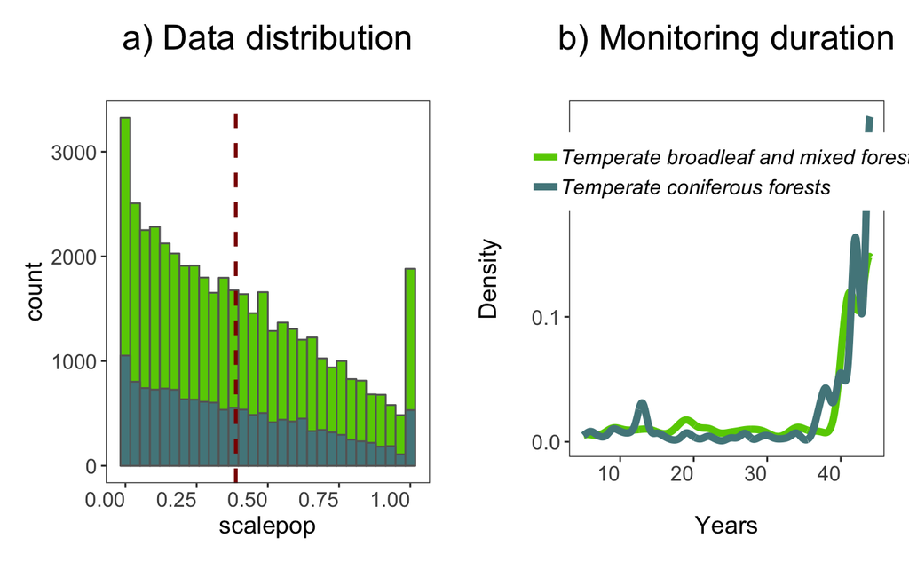

```r
# Arrange in a panel and save
forest.panel <- grid.arrange(forest.hist, duration.forests, ncol = 2)
```

```r
ggsave(forest.panel, file = "forest_panel.png", height = 5, width = 10)
```

# Further Analysis on Dataset

A couple notes: 1) when using the lm() function to a pipe –it is a linear model– it is neccesary to use data = at the end of the function to show that outcome of previous step gets piped 2) It is important to use ungroup() at end of pipe in order to protect dataset from getting changed

```r
install.packages("ggExtra")
# Calculate population change for each forest population
# 1785 models in one go!
# Using a pipe
forest.slopes <- LPD.forest %>%
  # Group by the key variables that we want to interate over
  group_by(decimal.latitude, decimal.longitude, class, species.name, id, duration, location.of.population) %>%
  # Create a linear model for each group
  do(mod = lm(scalepop ~ year, data = .)) %>%
  # Extract model coefficients using tidy() from the
  # *** tidy() function from the broom package ***
  tidy(mod) %>%
  # Filter out slopes and remove intercept values
  filter(term == "year") %>%
  # Get rid of the column term as we don't need it any more
  #  *** select() function from dplyr in the tidyverse ***
  dplyr::select(-term) %>%
  # Remove any groupings you've greated in the pipe
  ungroup()
```

## Visualize

[figure not shown]

```r
# Visualising model outputs ----
# Plotting slope estimates and standard errors for all populations and adding histograms along the margins
(all.slopes <- ggplot(forest.slopes, aes(x = duration, y = estimate)) +
         geom_pointrange(aes(ymin = estimate - std.error,
                             ymax = estimate + std.error),
                         alpha = 0.3, size = 0.3) +
         geom_hline(yintercept = 0, linetype = "dashed") +
         theme_LPD() +
         ylab("Population change\n") +
         xlab("\nDuration (years)"))
(density.slopes <- ggExtra::ggMarginal(
  p = all.slopes,
  type = 'density',
  margins = 'both',
  size = 5,
  col = 'gray40',
  fill = 'gray'
))
```

```r
# Save the plot
ggsave(density.slopes, filename = "slopes_duration.png", height = 6, width = 6)
```

idk why the graph is spitting out twice like this

# GGPlot with large datasets —-

### automating iterative commands

```r
# PART 2: Using pipes to make figures with large datasets ----
# Make histograms of slope estimates for each taxa -----
# Set up new folder for figures
# Set path to relevant path on your computer/in your repository
path1 <- "Taxa_Forest_LPD/"
# Create new folder
dir.create(path1)
```

group the data by class

then use do to use that dataset within ggplot

This section gets an error because it is expecting dataframes but that is ok

```r
# First we will do this using dplyr and a pipe
forest.slopes %>%
# Select the relevant data
dplyr::select(id, class, species.name, estimate) %>%
# Group by taxa
group_by(class) %>%
# Save all plots in new folder
do(ggsave(ggplot(., aes(x = estimate)) +
            # Add histograms
            geom_histogram(colour = "darkgreen", fill = "darkgreen", binwidth = 0.02) +
            # Use custom theme
            theme_LPD() +
            # Add axis lables
            xlab("Rate of population change (slopes)"),
            # Set up file names to print to
            filename = gsub("", "", paste0(path1, unique(as.character(.$class)),
                                          ".pdf")), device = "pdf"))
```

```
Error: Results 1, 2, 3, 4 must be data frames, not NULL
Call `rlang::last_error()` to see a backtrace
```

# Whenever doing copying and pasting of code it is a good idea to make a function of it

can apply functions using the purr package

## Select Data

```r
# Here we select the relevant data
# Let's get rid of the other levels of 'class'
forest.slopes$class <- as.character(forest.slopes$class)
# Selecting the relevant data and splitting it into a list
taxa.slopes <- forest.slopes %>%
  dplyr::select(id, class, estimate) %>%
  spread(class, estimate) %>%
  dplyr::select(-id)
```

Then apply this function to the data you want to apply it to use the function within purr map() to apply data to function

### shows mean per taxa

```r
taxa.mean <- purrr::map(taxa.slopes, ~mean(., na.rm = TRUE))
# This plots the mean population change per taxa
taxa.mean
```

```
$Amphibia
[1] 0.04476869

$Aves
[1] 0.003066424

$Mammalia
[1] 0.005025652

$Reptilia
[1] 0.01812443
```

```r
### Intro to the purrr package ----
# First let's write a function to make the plots
# *** Functional Programming ***
# This function takes one argument x, the data vector that we want to make a histogram
plot.hist <- function(x) {
  ggplot() +
  geom_histogram(aes(x), colour = "darkgreen", fill = "darkgreen", binwidth = 0.02) +
  theme_LPD() +
  xlab("Rate of population change (slopes)")
}
```

This section makes a function that we then apply data to using purr

```r
taxa.plots <- purrr::map(taxa.slopes, ~plot.hist(.))
# We need to make a new folder to put these figures in
path2 <- "Taxa_Forest_LPD_purrr/"
dir.create(path2)
```

```
'Taxa_Forest_LPD_purrr' already exists
```

There is a different way of using purr by putting together the path name and function using walk 2 this returns only the graph

```r
# *** walk2() function in purrr from the tidyverse ***
walk2(paste0(path2, names(taxa.slopes), ".pdf"), taxa.plots, ggsave)
```

# PART 3: Downloading and mapping data from large datasets

# There is a seperate package called coordinate cleaner that helps [verify coordinate data](https://ourcodingclub.github.io/2018/01/06/occurrence.html)

```r
install.packages("png")
```

# Select data you want

### use the package name :: function in order for functions not to be mixed up

# The rgbif is a package specifically for getting data from this one site- i think this what an api is but am not sure

```r
# Download species occurrence records from the Global Biodiversity Information Facility
# *** rgbif package and the occ_search() function ***
# You can increase the limit to get more records - 5000 takes a couple of minutes
deer.locations <- occ_search(scientificName = "Cervus elaphus", limit = 5000,
                             hasCoordinate = TRUE, return = "data") %>%
                  # Simplify occurrence data frame
                  dplyr::select(key, name, decimalLongitude,
                        decimalLatitude, year,
                individualCount, country)
```

```
Error in curl::curl_fetch_memory(x$url$url, handle = x$url$handle) :
  Timeout was reached: Operation timed out after 10003 milliseconds with 0 out of 0 bytes received
```

Extract only the deer population data

```r
# Data formatting & manipulation ----
# Filter out population data for chosen species - red deer
deer.data <- LPD_long2 %>%
  filter(species.name == "Cervus elaphus") %>%
  dplyr::select(id, species.name, location.of.population, year, pop)
# Filter out population estimates for chosen species - red deer
deer.slopes <- forest.slopes %>%
  filter(species.name == "Cervus elaphus")
```

## Maps in ggplot

mapping can be done using mapdata package geom_point function allows plotting of points on map - in this instance need to use it twice

[figure not shown]

```r
# Make an occurrence map and include the locations of the populations part of the Living Planet Database
(deer.map.LPD <- ggplot(deer.locations, aes(x = decimalLongitude, y = decimalLatitude)) +
    # Add map data
    borders("world", colour = "gray80", fill = "gray80", size = 0.3) +
    # Use custom map theme from ggthemes package
    theme_map() +
    # Add the points from the population change data
    geom_point(alpha = 0.3, size = 2, colour = "aquamarine3") +
    # Specify where the data come from when plotting from more than one data frame using data = ""
    geom_point(data = deer.slopes, aes(x = decimal.longitude, y = decimal.latitude),
               size = 2, colour = "darkgreen"))
```

### Getting Fancy with maps

ggrepel adds labels without overlap + rounded edges

```r
# Customising map to make it more beautiful ----
# Check site names
print(deer.slopes$location.of.population)
```

```
 [1] Pennsylvania Herd
 [2] Yellowstone National Park
 [3] Pinatelle d\xe4\xf3\xbbAllanche, Cantal region, France
 [4] Mount Rainier National Park
 [5] Switzerland
 [6] Hungary
 [7] The Petite Pierre National Reserve, France
 [8] Slovakia
 [9] Banff National Park, Alberta
[10] Banff National Park, Alberta
[11] Banff National Park, Alberta
[12] Banff National Park, Alberta
[13] Banff National Park, Alberta
[14] Polish part of Bia\x81\x89owie\x81_a Primeval Forest
[15] United Kingdom
[16] Regions of Plung\xed\x82, K\xed\x82dainiai, Mol\xed\x82tai, Ignalina (Utena), and Var\xed\x82na
[17] North Block of the Isle of Rum, Scotland
5369 Levels:  border of Alabama and Georgia"  North Island" ... Zvenigorod, Moscow Oblast
```

```r
# Beautify site names
deer.slopes$location.of.population <- recode(deer.slopes$location.of.population,
                                             "Northern Yellowstone National Park"
                         = "Yellowstone National Park")
deer.slopes$location.of.population <- recode(deer.slopes$location.of.population,
                                             "Mount Rainier National Park, USA"
                         = "Mount Rainier National Park")
deer.slopes$location.of.population <- recode(deer.slopes$location.of.population,
                                             "Bow Valley - eastern zone, Banff National Park, Alberta" =
                         "Banff National Park, Alberta")
deer.slopes$location.of.population <- recode(deer.slopes$location.of.population,
                                             "Bow Valley - western zone, Banff National Park, Alberta" =
                         "Banff National Park, Alberta")
deer.slopes$location.of.population <- recode(deer.slopes$location.of.population,
                                             "Bow Valley - central zone, Banff National Park, Alberta" =
                         "Banff National Park, Alberta")
deer.slopes$location.of.population <- recode(deer.slopes$location.of.population,
                                             "Study area within Bow Valley, Banff National Park, Alberta" =
                         "Banff National Park, Alberta")
deer.slopes$location.of.population <- recode(deer.slopes$location.of.population,
                                             "Bow Valley watershed of Banff National Park, Alberta" =
                         "Banff National Park, Alberta")
# Load packages for adding images
packs <- c("png","grid")
lapply(packs, require, character.only = TRUE)
```

```
[[1]]
[1] TRUE

[[2]]
[1] TRUE
```

```r
# Load red deer icon
icon <- readPNG("reddeer.png")
```

```
Error in readPNG("reddeer.png") : unable to open reddeer.png
```

```r
# Update map
# Note - this takes a while depending on your computer
(deer.map.final <- ggplot(deer.locations, aes(x = decimalLongitude, y = decimalLatitude)) +
    # For more localized maps use "worldHires" instead of "world"
    borders("world", colour = "gray80", fill = "gray80", size = 0.3) +
    theme_map() +
    geom_point(alpha = 0.3, size = 2, colour = "aquamarine3") +
    # We are specifying the data frame for the labels - one site has three monitored populations
    # but we only want to label it once so we are subsetting using data = deer.slopes[c(2, 4, 5, 9),]
    # to get only the first rows number 2, 4, 5 and 9
    geom_label_repel(data = deer.slopes[c(2, 4, 5, 9),], aes(x = decimal.longitude, y = decimal.latitude,
                                                     label = location.of.population),
                     box.padding = 1, size = 5, nudge_x = 1,
                     # We are specifying the size of the labels and nudging the points so that they
                     # don't hide data points, along the x axis we are nudging by one
                     min.segment.length = 0, inherit.aes = FALSE) +
    # We can recreate the shape of a dropped pin by overlaying a circle and a triangle
    geom_point(data = deer.slopes, aes(x = decimal.longitude, y = decimal.latitude + 0.6),
               size = 4, colour = "darkgreen") +
    geom_point(data = deer.slopes, aes(x = decimal.longitude, y = decimal.latitude - 0.3),
               size = 3, fill = "darkgreen", colour = "darkgreen", shape = 25) +
    # Adding the icon using the coordinates on the x and y axis
    annotation_custom(icon, xmin = -210, xmax = -100, ymin = -60 , ymax = -30) +
    # Adding a title
    labs(title = "a. Red Deer GBIF occurrences", size = 12))
```

```
Error in layer(data = dummy_data(), stat = StatIdentity, position = PositionIdentity,  :
  object 'icon' not found
```

```r
# Visualise population trends ----
# Visualising the population trends of four deer populations
# Let's practice functional programming here
# *** Functional Programming ***
# Let's make a function to make the population trend plots
# First we need to decide what values the function needs to take
# x - The population data
# y - the slope value
# z - the location of the monitoring
# This function needs to take three arguments
# Let's make the ggplot function
pop.graph <- function(x, y, z) {
  # Make a ggplot graph with the 'x'
  ggplot(x, aes(x = year, y = pop)) +
  # Shape 21 chooses a point with a black outline filled with aquamarine
  geom_point(shape = 21, fill = "aquamarine3", size = 2) +
  # Adds a linear model fit, alpha controls the transparency of the confidence intervals
  geom_smooth(method = "lm", colour = "aquamarine3", fill = "aquamarine3", alpha = 0.4) +
  # Add the monitoring location 'y' into the plot
  labs(x = "", y = "Individuals\n", title = paste("c. ", y, "\n"), size = 7) +
  # Set the y limit to the maximum population for each 'x'
  ylim(0, max(x$pop)) +
  # Set the x limit to the range of years of data
  xlim(1970, 2010) +
  # Add the slope 'y' into the plot
  annotate("text", x = 1972, y = 0,  hjust = 0, vjust = -2, label = paste("Slope =", z), size = 3) +
  theme_LPD() +
  theme(plot.title = element_text(size=12), axis.title.y = element_text(size=10))
}
```

```r
# Find all unique ids for red deer populations
unique(deer.slopes$id)
```

```
 [1]  3423  6395 11180  3425 11170 11169 11176 11167  4383  4384  4382 12738 13289 11480 11166 11558 11178
```

```r
# Create an object each of the unique populations
# Deer population 1 - Northern Yellowstone National Park
deer1 <- filter(deer.data, id == "6395")
slope_deer1 <- round(deer.slopes$estimate[deer.slopes$id == "6395"],2)
location_deer1 <- deer.slopes$location.of.population[deer.slopes$id == "6395"]
yellowstone <- pop.graph(deer1, location_deer1, slope_deer1)
# Deer population 2 - Mount Rainier National Park, USA
deer2 <- filter(deer.data, id == "3425")
slope_deer2 <- round(deer.slopes$estimate[deer.slopes$id == "3425"],2)
location_deer2 <- deer.slopes$location.of.population[deer.slopes$id == "3425"]
rainier <- pop.graph(deer2, location_deer2, slope_deer2)
# Deer population 3 - Switzerland
deer3 <- filter(deer.data, id == "11170")
slope_deer3 <- round(deer.slopes$estimate[deer.slopes$id == "11170"],2)
location_deer3 <- deer.slopes$location.of.population[deer.slopes$id == "11170"]
switzerland <- pop.graph(deer3, location_deer3, slope_deer3)
# Deer population 4 - Banff National Park, Alberta (there are more populations here)
deer4 <- filter(deer.data, id == "4383")
slope_deer4 <- round(deer.slopes$estimate[deer.slopes$id == "4383"],2)
location_deer4 <- deer.slopes$location.of.population[deer.slopes$id == "4383"]
banff <- pop.graph(deer4, location_deer4, slope_deer4)
```

```r
# Create panel of all graphs
# Makes a panel of the map and occurrence plot and specifies the ratio
# i.e., we want the map to be wider than the other plots
# suppressWarnings() suppresses warnings in the ggplot call here
row1 <- grid.arrange(deer.map.final, occurrences, ncol = 2, widths = c(1.96, 1.04))
```

```
Error in arrangeGrob(...) : object 'deer.map.final' not found
```

can use kable or pander in RMarkdown